# (Bike_sharing Data Exploration)

## Preliminary Wrangling

> This document explores a dataset dealing with a bike sharing system with big data contains millions of records.

```python
# import all packages and set plots to be embedded inline
import numpy as np
import pandas as pd
import matplotlib.pyplot as plt
import seaborn as sb

%matplotlib inline
```

> I looked up for the data in many sources and combined the convenient sheets together.

> I combined the data and stored them in a csv file then commented the line i used to call the function of the combination

```python
## combining the data
path =  "data2"
last_csv = "new_combined_csv.csv"

def get_csv_file(path, last_csv):
    os.chdir(path)
    extension = 'csv'
    all_filenames = [i for i in glob.glob('*.{}'.format(extension))]
#combine all files in the list
    combined_csv = pd.concat([pd.read_csv(f) for f in all_filenames ])
#export to csv
    combined_csv.to_csv(last_csv , index=False, encoding='utf-8-sig')

# # get_csv_file(path, last_csv)
```

```python
## loading them using pandas
df = pd.read_csv("new_combined_csv.csv")
df.head(5)
```

|  | trip_id | start_time | end_time | bikeid | tripduration | from_station_id | from_station_name | to_station_id | to_station_name | usertype | gender | birthyear |
| --- | --- | --- | --- | --- | --- | --- | --- | --- | --- | --- | --- | --- |
| 0 | 21742443 | 2019-01-01 00:04:37 | 2019-01-01 00:11:07 | 2167 | 390.0 | 199 | Wabash Ave & Grand Ave | 84 | Milwaukee Ave & Grand Ave | Subscriber | Male | 1989.0 |
| 1 | 21742444 | 2019-01-01 00:08:13 | 2019-01-01 00:15:34 | 4386 | 441.0 | 44 | State St & Randolph St | 624 | Dearborn St & Van Buren St (*) | Subscriber | Female | 1990.0 |
| 2 | 21742445 | 2019-01-01 00:13:23 | 2019-01-01 00:27:12 | 1524 | 829.0 | 15 | Racine Ave & 18th St | 644 | Western Ave & Fillmore St (*) | Subscriber | Female | 1994.0 |
| 3 | 21742446 | 2019-01-01 00:13:45 | 2019-01-01 00:43:28 | 252 | 1,783.0 | 123 | California Ave & Milwaukee Ave | 176 | Clark St & Elm St | Subscriber | Male | 1993.0 |
| 4 | 21742447 | 2019-01-01 00:14:52 | 2019-01-01 00:20:56 | 1170 | 364.0 | 173 | Mies van der Rohe Way & Chicago Ave | 35 | Streeter Dr & Grand Ave | Subscriber | Male | 1994.0 |

```python
## checking the shape and types of my data
print(df.shape)
print(df.info())
```

```
(2005787, 12)
<class 'pandas.core.frame.DataFrame'>
RangeIndex: 2005787 entries, 0 to 2005786
Data columns (total 12 columns):
 #   Column             Dtype
---  ------             -----
 0   trip_id            int64
 1   start_time         object
 2   end_time           object
 3   bikeid             int64
 4   tripduration       object
 5   from_station_id    int64
 6   from_station_name  object
 7   to_station_id      int64
 8   to_station_name    object
 9   usertype           object
 10  gender             object
 11  birthyear          float64
dtypes: float64(1), int64(4), object(7)
memory usage: 183.6+ MB
None
```

```python
## change tripduration fro object to float
df['tripduration']=df['tripduration'].str.replace(",","").astype(float)
```

```python
df.info()
```

```
<class 'pandas.core.frame.DataFrame'>
RangeIndex: 2005787 entries, 0 to 2005786
Data columns (total 12 columns):
 #   Column             Dtype
---  ------             -----
 0   trip_id            int64
 1   start_time         object
 2   end_time           object
 3   bikeid             int64
 4   tripduration       float64
 5   from_station_id    int64
 6   from_station_name  object
 7   to_station_id      int64
 8   to_station_name    object
 9   usertype           object
 10  gender             object
 11  birthyear          float64
dtypes: float64(2), int64(4), object(6)
memory usage: 183.6+ MB
```

```python
## cleaning my dataset
df.duplicated().sum()     # checking for duplicates
```

```
0
```

```python
## checking for null values
df.isnull().sum()
```

```
trip_id                   0
start_time                0
end_time                  0
bikeid                    0
tripduration              0
from_station_id           0
from_station_name         0
to_station_id             0
to_station_name           0
usertype                  0
gender               307061
birthyear            296117
dtype: int64
```

```python
df = df.dropna()
```

```python
df.isnull().sum()
```

```
trip_id              0
start_time           0
end_time             0
bikeid               0
tripduration         0
from_station_id      0
from_station_name    0
to_station_id        0
to_station_name      0
usertype             0
gender               0
birthyear            0
dtype: int64
```

```python
## convert usertype and gender into ordered categorical types, also bikeid and from_station_name into str

def df_type (df):
    df['bikeid'] = df['bikeid'].astype('str')
    df['from_station_name'] = df['from_station_name'].astype('str')
    df['to_station_name'] = df['to_station_name'].astype('str')
    df['usertype'] = df['usertype'].astype('category')
    df['gender'] = df['gender'].astype('category')
    return df

df = df_type(df)
```

```python
## handeling datetime features from start_time and  end_time columns

drop_list = ['start_time', 'end_time']
def y_m_d(df):
    df['start_time'] = pd.to_datetime(df['start_time'])
#     df['start_hr'] = df.start_time.dt.strftime('%H')
    df['start_year'] = (df.start_time.dt.strftime('%Y')).astype('int')
    df['start_day'] = df.start_time.dt.strftime('%A')
    df['start_month'] = df.start_time.dt.strftime('%B')

    df['end_time'] = pd.to_datetime(df['end_time'])
    df['end_year'] = df.end_time.dt.strftime('%Y')
    df['end_day'] = df.end_time.dt.strftime('%A')
    df['end_month'] = df.end_time.dt.strftime('%B')
    df.drop(drop_list, axis=1, inplace=True)
    return df
df = y_m_d(df)
```

```python
df.head(5)
```

|  | trip_id | bikeid | tripduration | from_station_id | from_station_name | to_station_id | to_station_name | usertype | gender | birthyear | start_year | start_day | start_month | end_year | end_day | end_month |
| --- | --- | --- | --- | --- | --- | --- | --- | --- | --- | --- | --- | --- | --- | --- | --- | --- |
| 0 | 21742443 | 2167 | 390.0 | 199 | Wabash Ave & Grand Ave | 84 | Milwaukee Ave & Grand Ave | Subscriber | Male | 1989.0 | 2019 | Tuesday | January | 2019 | Tuesday | January |
| 1 | 21742444 | 4386 | 441.0 | 44 | State St & Randolph St | 624 | Dearborn St & Van Buren St (*) | Subscriber | Female | 1990.0 | 2019 | Tuesday | January | 2019 | Tuesday | January |
| 2 | 21742445 | 1524 | 829.0 | 15 | Racine Ave & 18th St | 644 | Western Ave & Fillmore St (*) | Subscriber | Female | 1994.0 | 2019 | Tuesday | January | 2019 | Tuesday | January |
| 3 | 21742446 | 252 | 1783.0 | 123 | California Ave & Milwaukee Ave | 176 | Clark St & Elm St | Subscriber | Male | 1993.0 | 2019 | Tuesday | January | 2019 | Tuesday | January |
| 4 | 21742447 | 1170 | 364.0 | 173 | Mies van der Rohe Way & Chicago Ave | 35 | Streeter Dr & Grand Ave | Subscriber | Male | 1994.0 | 2019 | Tuesday | January | 2019 | Tuesday | January |

```python
## counting the age from start_year and birthyear features
df['age'] = df['start_year'] - df['birthyear'].astype(int)
df.drop(['birthyear'], axis=1, inplace=True)              # droping the birthyear column

df.head(5)
```

|  | trip_id | bikeid | tripduration | from_station_id | from_station_name | to_station_id | to_station_name | usertype | gender | start_year | start_day | start_month | end_year | end_day | end_month | age |
| --- | --- | --- | --- | --- | --- | --- | --- | --- | --- | --- | --- | --- | --- | --- | --- | --- |
| 0 | 21742443 | 2167 | 390.0 | 199 | Wabash Ave & Grand Ave | 84 | Milwaukee Ave & Grand Ave | Subscriber | Male | 2019 | Tuesday | January | 2019 | Tuesday | January | 30 |
| 1 | 21742444 | 4386 | 441.0 | 44 | State St & Randolph St | 624 | Dearborn St & Van Buren St (*) | Subscriber | Female | 2019 | Tuesday | January | 2019 | Tuesday | January | 29 |
| 2 | 21742445 | 1524 | 829.0 | 15 | Racine Ave & 18th St | 644 | Western Ave & Fillmore St (*) | Subscriber | Female | 2019 | Tuesday | January | 2019 | Tuesday | January | 25 |
| 3 | 21742446 | 252 | 1783.0 | 123 | California Ave & Milwaukee Ave | 176 | Clark St & Elm St | Subscriber | Male | 2019 | Tuesday | January | 2019 | Tuesday | January | 26 |
| 4 | 21742447 | 1170 | 364.0 | 173 | Mies van der Rohe Way & Chicago Ave | 35 | Streeter Dr & Grand Ave | Subscriber | Male | 2019 | Tuesday | January | 2019 | Tuesday | January | 25 |

```python
df.shape
```

```
(1698725, 16)
```

```python
## checking how many subscribers and members are in this year
df.usertype.value_counts()
```

```
Subscriber    1478675
Customer       220050
Name: usertype, dtype: int64
```

```python
## checking which gender is most using bike sharing
df.gender.value_counts()
```

```
Male      1235792
Female     462933
Name: gender, dtype: int64
```

```python
## checking the days of the week
df.start_day.value_counts()
```

```
Thursday     277978
Wednesday    276414
Tuesday      268616
Friday       258832
Monday       253705
Saturday     199819
Sunday       163361
Name: start_day, dtype: int64
```

```python
## checking the months recorded in this year
df.start_month.value_counts()
```

```
August       483183
July         453660
September    416525
March        152659
January       99185
February      93513
Name: start_month, dtype: int64
```

```python
## checking the most common ages in the dataset
df.age.value_counts()
```

```
27     107384
30     100312
26      98173
29      95743
28      95624
        ...
130         3
94          2
84          2
99          1
90          1
Name: age, Length: 82, dtype: int64
```

```python
df.to_csv('new_data.csv' , index=False, encoding='utf-8-sig')
```

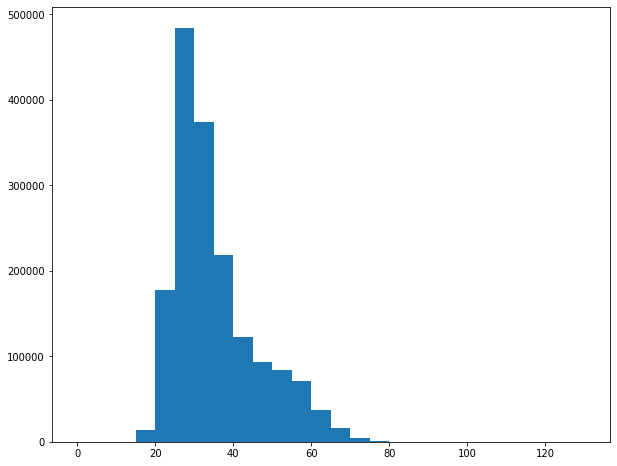

```python
## checking for outliers in customers depending on the age
plt.figure(figsize=[10, 8])
bins = np.arange(0, df['age'].max()+5, 5)
plt.hist(df['age'], bins=bins);
```

### Structure of my dataset?

> I collected the data from many sources as i had data from 2013 to 2020 .. some have different features and some has the same features.

> Collected the data with the same features with the function i made above, but it used all my ram and my system errupted as the data was over the 7 million record.. so i had to decrease the data i combine so I used the data for the same year (2019) and collected about 2 million records and i think that should be enough.

> after cleaning the data i found it contains 1698725 records and 16 columns the most numerical data that matters are the (tripduration, and age) .. with categorical data in (gender, and usertype) and string data in the rest.

### What is/are the main feature(s) of interest in your dataset?

> I think the duration, gender, and usertype may affect using this system

### What features in the dataset do you think will help support your investigation into your feature(s) of interest?

> I suppose the age, months, and days can help me explore the data .. as some people might like to ride in certain days and months rather than the others .. the same young people may differ from the elder ones.

## Univariate Exploration

> In this section, investigate distributions of individual variables. If you see unusual points or outliers, take a deeper look to clean things up and prepare yourself to look at relationships between variables.

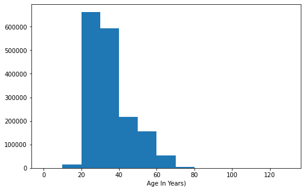

```python
# start with a standard-scaled plot
binsize = 10
bins = np.arange(0, df['age'].max()+binsize, binsize)

plt.figure(figsize=[8, 5])
plt.hist(data = df, x = 'age', bins = bins)
plt.xlabel('Age In Years)')
plt.show()
```

```python
df[df.tripduration > 1000000]
```

|  | trip_id | bikeid | tripduration | from_station_id | from_station_name | to_station_id | to_station_name | usertype | gender | start_year | start_day | start_month | end_year | end_day | end_month | age |
| --- | --- | --- | --- | --- | --- | --- | --- | --- | --- | --- | --- | --- | --- | --- | --- | --- |
| 19374 | 21764881 | 544 | 1231180.0 | 59 | Wabash Ave & Roosevelt Rd | 24 | Fairbanks Ct & Grand Ave | Subscriber | Male | 2019 | Saturday | January | 2019 | Saturday | January | 47 |
| 84098 | 21839757 | 6157 | 1609620.0 | 242 | Damen Ave & Leland Ave | 242 | Damen Ave & Leland Ave | Subscriber | Male | 2019 | Friday | January | 2019 | Wednesday | February | 45 |
| 86090 | 21842257 | 6435 | 2592880.0 | 627 | LaSalle Dr & Huron St (*) | 360 | DIVVY Map Frame B/C Station | Subscriber | Male | 2019 | Sunday | January | 2019 | Tuesday | February | 27 |
| 88324 | 21845123 | 5419 | 5646180.0 | 390 | Wentworth Ave & 63rd St | 120 | Wentworth Ave & Cermak Rd (Temp) | Subscriber | Male | 2019 | Monday | January | 2019 | Thursday | March | 28 |
| 114411 | 21878086 | 5633 | 3095670.0 | 110 | Dearborn St & Erie St | 283 | LaSalle St & Jackson Blvd | Subscriber | Male | 2019 | Monday | February | 2019 | Tuesday | March | 29 |
| ... | ... | ... | ... | ... | ... | ... | ... | ... | ... | ... | ... | ... | ... | ... | ... | ... |
| 1680869 | 24886097 | 1008 | 1018938.0 | 420 | Ellis Ave & 55th St | 671 | HUBBARD ST BIKE CHECKING (LBS-WH-TEST) | Customer | Male | 2019 | Tuesday | September | 2019 | Sunday | September | 25 |
| 1731181 | 24938369 | 1856 | 1637940.0 | 180 | Ritchie Ct & Banks St | 564 | Racine Ave & 65th St | Customer | Male | 2019 | Friday | September | 2019 | Wednesday | October | 21 |
| 1742053 | 24949802 | 2255 | 1561919.0 | 148 | State St & 33rd St | 671 | HUBBARD ST BIKE CHECKING (LBS-WH-TEST) | Customer | Male | 2019 | Saturday | September | 2019 | Wednesday | October | 21 |
| 1863735 | 25075937 | 982 | 1777405.0 | 592 | Knox Ave & Montrose Ave | 373 | Kedzie Ave & Chicago Ave | Subscriber | Female | 2019 | Saturday | September | 2019 | Friday | October | 33 |
| 1932252 | 25147001 | 1846 | 1563980.0 | 345 | Lake Park Ave & 56th St | 322 | Kimbark Ave & 53rd St | Customer | Male | 2019 | Wednesday | September | 2019 | Sunday | October | 25 |

84 rows × 16 columns